# Outline: migration paper

Hannah Olson-Williams

2023-03-20

# ABSTRACT

Can temporal changes in place-based health outcomes be explained by population mobility? Communities across the United States experience differential rates of inflow and outflow migration which is often connected to resources and structural factors associated with health. To better understand how human migration may affect the health of places over time, we joined county-to-county migration flow data publicly available from the IRS with county-level race-specific mortality rates from the CDC WONDER database. We then were able to create and assess a novel county-level “migration effect” on longitudinal race-ethnicity mortality trends. Using methods from sensitivity analysis, we were able to establish a “selection” effect at the county level.

# INTRODUCTION

Data for mortality is historically easier to collect and more accurate than other measures of human health. Death has a clear and common definition making it possible to consistently estimate mortality rates across countries, health systems, and time periods.CITE? Mortality as a measure of length of life also has important policy and health equity implications and can be used to assess which individuals or groups are likely to live longest and which individuals or groups may be most in need of additional care.CITE? Thus, mortality rates are often the first place researchers turn when testing a new method. The methods used to estimate and predict mortality are various and numerous, among them singular value decomposition, random walk framework, tensor factorization, agent based modelling - just to name a few.

Autoregressive models, such as those used in this paper, have commonly been used to estimate mortality rates; for instance, in a 2011 paper, county-level mortality was modeled using spatial autoregressive models in which each county’s relative position to other counties as well as its historical mortality rates were taken into account (Yang, Jensen, Haran). Another similar paper (Sparks and Sparks) used an autoregressive model with county-level estimates of mortality that were standardized for measures of income and employment, population density and rurality, and race/ethnicity. Similarly, early in the COVID-19 pandemic, researchers used a spatial autoregressive model to assess the relationships between county-level COVID-19 mortality rates and county-level sociodemographic characteristics (Fielding-Miller, Sundaram, Brouwer). This method has also been extended to age-group and country-level data to explain cohort effects within countries. (Li and Lu 2017) Finally, a 2020 paper adapted this method using age-group data to estimate country-level life expectancy more efficiently, more accurately, and with greater precision for younger populations (Shi).

In this paper, we extend previous autoregressive models to account for county interconnectedness. We develop a novel “migration term” which accounts for the mortality rates of individuals who have either moved to a county of interest during a given time period. We then use this migration term to assess the possibility of health-related **selection of counties as destinations for migration**.(bolded because maybe there are better ways to describe?)

According to Lee’s theory of migration24, migration is selective, meaning that the individuals who migrate are not a random sample of the population of the origin. Migration occurs in response to a “push” or a “pull” – migrants are “pushed” to leave an origin and “pulled” to a destination. “Pull” factors are more often associated with positive selection; migrants who are “pulled” to a destination due to perceived benefits are more likely to have high income or education status. Contrarily, migrants who are “pushed” to leave an origin are likely to have faced hardship in some form. In some cases, this is a negatively selected group including individuals who have lost jobs or suffered from climate change events; in other cases, an entire population may be “pushed” to migrate due to war or famine. Migration is often bimodal in that only the most advantaged and the least advantaged individuals relocate. This logic could be extended to the health distribution of migrants: only the most and least healthy individuals migrate.

Selection for migration has been studied many times before. One such study simulated the effects of climate change on population dynamics using a model capturing “emigrant self-selection by health” which could be either positive or negative - positive meaning that a migrant was likely to be healthier than their non-migrant peers or negative meaning that a migrant was likely to have migrated in search of better health.(Reuveny)

Another study of internal migration patterns in Indonesia found that with respect to health, young migrants were positively selected to migrate while older migrants were negatively selected to migrate25. In other words, as age increases, older migrants are more likely to be “pushed” to leave an origin, possibly due to adverse, health while young migrants are more likely to be “pulled” to a destination, possibly seeking jobs. Thus, we use age-adjusted mortality rates (available through CDC WONDER) in an effort to reduce the effects of age.

According to Norman and colleagues, migrants who move from more resource depleted regions to less resource depleted regions have better health on average than the population in their destination while migrants who move from less depleted regions to more depleted regions have worse health on average than the population in their destination.26 Additionally, when the barriers between origin and destination are particularly high, migrants are often healthier on average than the people living in their destination, either because they have been selected through the migration process or because unhealthy people are less likely to choose to move when the barriers are high.27

In our paper, we assess migration where the barriers for migration are relatively low and relatively constant: between United States counties. Migration between counties typically does not require overcoming hazardous terrain or attainment of visas and other government documentation.CITE Data accounting for demographic patterns in internal US migration is difficult to obtain or largely unavailable. Though there are 5-year estimates available from the American Community Survey, county-to-county migration flow data are only available for each year from the IRS which does not include individuals who do not file taxes. CITE. Thus, because our unit of analysis is a US county and because our data source (IRS) includes individuals who have filed taxes and are relocating within the US, we assume that any selection that occurs is the result of “self-selection” rather than selection by or through the process of migrating itself - in other words, individuals who migrate are migrating because they have chosen to migrate, and there is little to no chance of removal of migrants from the potential migrant pool during the process of migrating.

# METHODS

### DATA

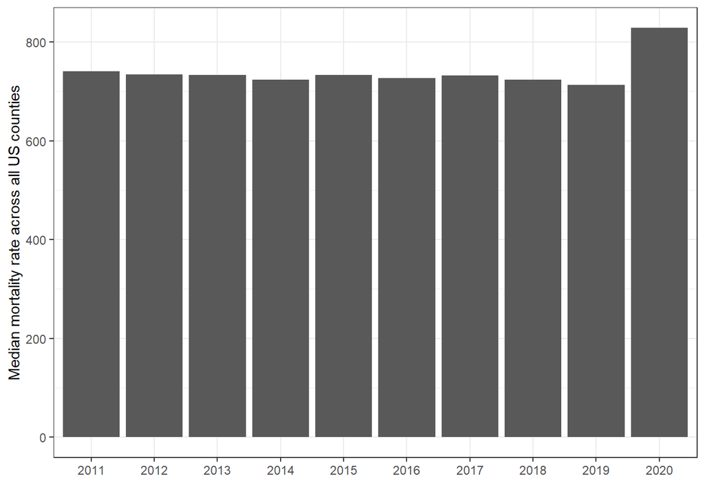

### VARIABLES AND MODELS

To assess migration, we created a novel “migration term” which can be thought of as a weighted average of the mortality rates of all counties that have migrants to each destination county. This approach requires the assumption that all migration occurs at random - ie the average mortality rate of any group of migrants from a specific origin county is approximately equivalent to the mortality rate of their origin county.  
We calculated the following for each change in year and for each destination county:

$$migration = \frac{ \sum_{d=1}^{k} { out_o rate_o0 } + rate_d0 (pop_d0 -
out_d) }{ \sum_{d=1}^{k} { out_o } + (pop_d0 - out_d)}$$

where  
$out_o$ represents the number of migrants from a unique origin county $o$ who migrated to a destination county $d$ between two years of interest.  
$rate_o0$ is the mortality rate of an unique origin county $o$ at initial year $0$  
$rate_d0$ is the mortality rate of an unique destination county $d$ at initial year $0$  
$pop_d0$ is the population of an unique destination county $d$ at initial year $0$  
$out_d$ is the number of migrants who left each unique destination county between two years of interest.

The resulting weighted average is highly correlated with county-level mortality. **note here about multicollinearity??**

We used a multilevel autoregressive model to explain county and race-specific age-adjusted mortality rates across 3000 US counties. We tested several models and used BIC to determine the best fitting model. BIC is commonly used to determine models with greatest explanatory power (CITE).  
Our initial model included a random intercept for each destination county and random slope for each time covariate. We include random intercepts for each destination county in an attempt to account for some variation between counties, as recommended by Greenberg’s assessment of best practices for ecological studies CITE. We then iteratively added splines for the prior year’s average county-level mortality rate and the migration term. Our initial model is similar to autoregressive county-level mortality models used by (Sparks and Sparks), (Yang, Jensen, Haran), and (Fielding-Miller, Sundaram, Brouwer).

First we compared models without a migration term to models with a migration term and determined that models with and without a migration term performed approximately equivalently, with the lowest BIC values occurring for models with splines with 5 degrees of freedom for both the migration term and mortality.

Without the migration term included:

```
##           df      BIC
## m1_nomig  14 287060.9
## m1_nomig3 16 287029.5
## m1_nomig4 17 287019.4
## m1_nomig5 18 287014.7
## m1_nomig6 19 287018.6
## m1_nomig7 20 287022.2
## m1_nomig9 22 287026.3
```

The best performing model (lowest BIC) has a spline with 5 degrees of freedom. Predicted data for this model is shown below.

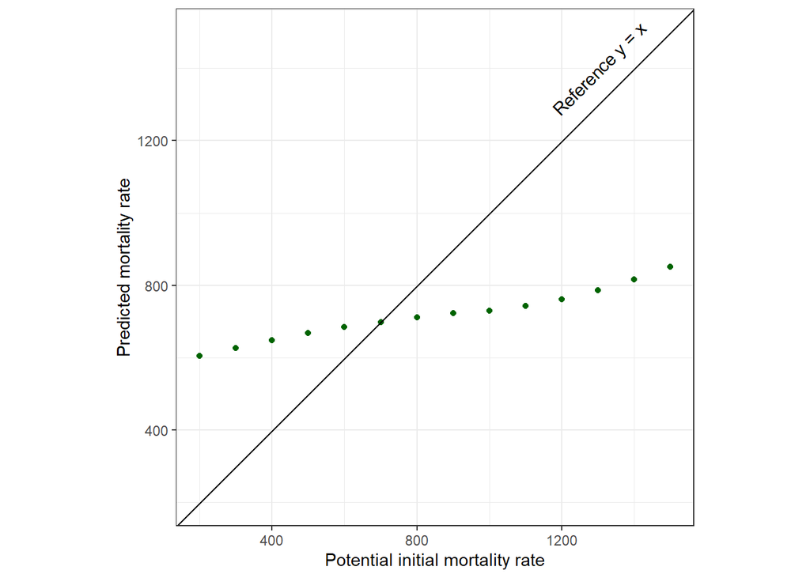

As we can see, prior (or “initial”) age-adjusted mortality rate affects predicted mortality rate, with lower initial mortality rates being associated with lower predicted mortality rates. Though we might expect the relationship between prior and predicted age-adjusted mortality to be close to 1 to 1, in our model, this is not the case. In the plot above, the y=x reference line highlights this gap. Our model reduces the noise at the extremes; all predicted values are centered around the mean.

Next we compare models that do not include mortality rates and instead include a weighted average migration term. The BIC scores of these models are shown below:

```
##            df      BIC
## m1_norate  14 287053.7
## m1_norate3 16 287027.3
## m1_norate4 17 287018.5
## m1_norate5 18 287015.0
## m1_norate6 19 287019.0
## m1_norate7 20 287022.5
## m1_norate9 22 287026.9
```

Again, the best performing model with migterm instead of mortality has a spline with 5 degrees of freedom. We display the predicted data for this migterm only model in combination with the predicted data from the prior mortality only model.

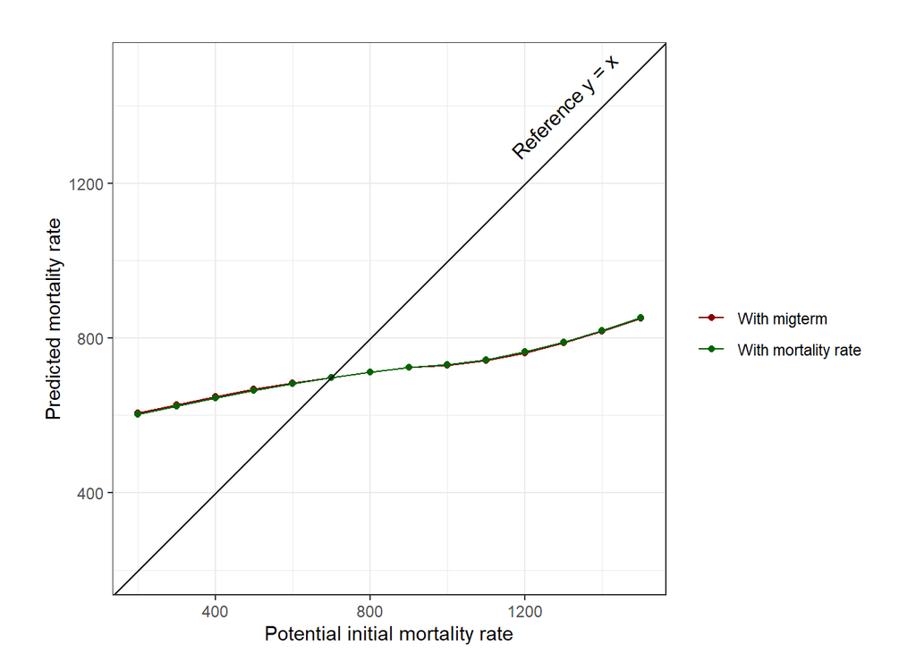

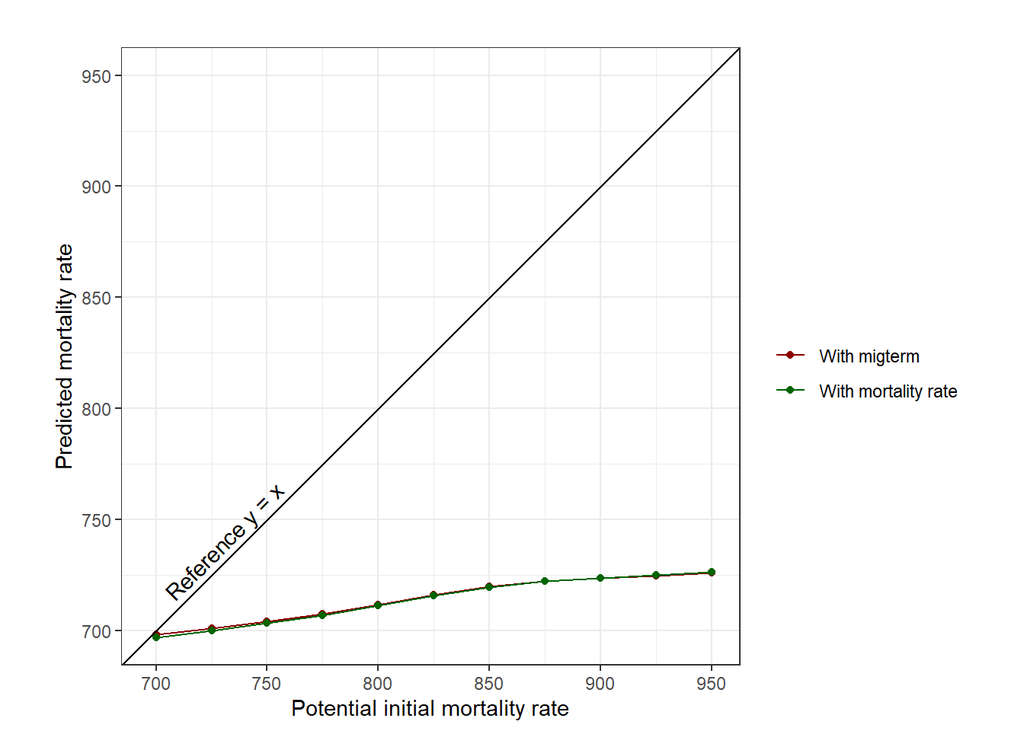

As we can see, the predicted age-adjusted mortality rates appear to be unaffected by the modelling choice of whether to include the migterm or the prior year’s mortality rate. Even after emphasizing potential initial mortality rates that are between the 25% and 75% percentile, it is difficult to distinguish between the two models.

When splines were included for both migration and mortality, BIC continued to drop, suggesting that migration continued to have an effect on the explanatory power of the model.

```
##               df      BIC
## m1_nomig5     18 287014.7
## m1_norate5    18 287015.0
## m1_spline22   17 286890.5
## m1_spline33   19 286726.2
## m1_spline44   21 286714.0
## m1_spline55   23 286717.0
## m1_spline1212 37 286750.3
```

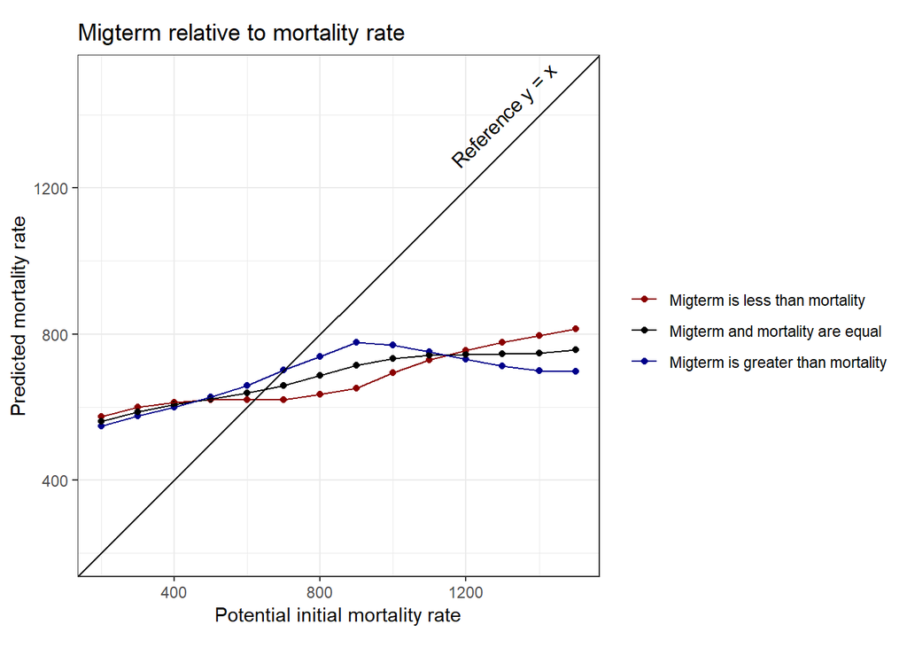

Taking the center of the plot to be closest to “truth”, we see that when the migterm is greater than mortality, the predicted mortality rate is larger than when the migterm is less than or equal to mortality. Of course, we know that the migterm will only be greater than mortality when the average mortality rate of all origin counties is greater than the initial mortality rate of each destination. Thus, when migration occurs from “less healthy” origin counties, we predict that mortality will become worse in destination counties as well. This phenomenon is more clearly illustrated in the plot below which shows only the initial mortality rates between the 10th and 90th percentile.

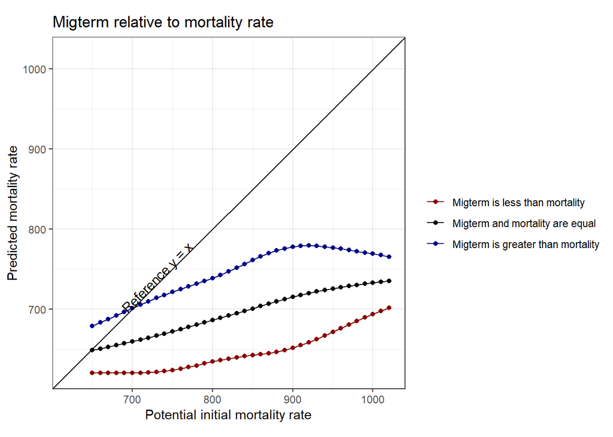

### SELECTION

We use county-level data because that is what is available, but also because we cannot know exactly which individuals are in each county at time 0 and at time 1, creating treatment and outcome groups that differ at the individual-level, but not at the county-level. Of course there is information lost when using group-level data, and the downsides of such an ecological study design have been enumerated many times previously (CITE); however, by studying county-level data, we can draw attention to environmental county-level health factors - factors that are likely to have different effects when comparing individuals but may remain largely constant when comparing groups or counties. **more here about ecological fallacy, maup, bimodal patterns???** Additionally, by using a multi-level model, one possible partial solution to ecological fallacy bias as outlined by Greenland CITE, we account for some of the variation across and within groups.

First, we must assume that our system is closed - the sum of county populations at time 0 (treatment) is equal to the sum of county populations at time 1 (outcome). This is a heroic assumption, but it is necessary given our data source - we do not readily have information on county-level international migration, and while we could include county-level birth and death data, this is not necessary since we our county-to-county migration flow data includes only individuals who have filed taxes, and therefore already systematically reduces the likelihood that we count individuals who are either very old or very young. CITE

In order to test for selection bias among the group that are available at time 1 (the time period after migration - the “outcome” group) we require a second initial assumption: all counties experience the same rates of inflow and outflow migration. Anecdotally, we know that not all counties experience the same rates of inflow and outflow - some counties are more desirable, attracting many new residents from counties that are less desirable which experience high rates of outflow.

### Model of migration at random

$$E[y_t | x_{t+1}=j] =
\sum_k{E[y_t|x_{t+1}=j, x_t = k]} * P(x_t= k | x_{t+1} = j)$$

The expected value of mortality at time t given that a migrant moved to j at time t+1 is equal to the sum of the expected mortality at time t given that the migrant moved to j at time t+1 and came from origin k (of which there are multiple which we sum across) times the probability that the migrant was at origin k at time t and moved to j at time t+1.

However, when selection bias occurs, the probability of migration depends on health. Therefore, the desired predicted outcome and the inputs are not independent.

##### ideas for what to do about insignificance/problematic of migterm

- subset to focus on counties with “extreme” patterns of migration and then look at the effects of mig on health
- skip the term all together and do a simulation instead (see “agent based sim.Rmd”)

Thus, we test two different scenarios, borrowed from Cornfield:

### Defining the outcome

1. outcome variable: mortality AFTER migration ; but this is difficult to parse because migration is constant.

but we want the “outcome” of our analyses to be a) a term assessing the average effect of migration on county-level health outcomes; and b) a quantitative understanding of how selection bias may affect longitudinal trends - ie a percent that the relationship between mortality at time 0 and mortality at time1 may be explainable through unmeasured confounding (ie migration)

2. a model for mortality rates: we could potentially use any county-level health outcome (health outcomes available through CHRR include premature death, life expectancy, child mort, infant mort, poor/fair health, poor mh days, poor ph days, low bw, physical distress, mental distress, diabetes prevalence, hiv prevalence); however, mortality measures are the only measures of county-level health outcomes for which subgroup (race, age) are available. We could potentially examine a health factor in place of a health outcome - high school completion has strong potential; other strong variables: children in poverty, unemployment, severe housing cost burden. I think using one of these variables as the primary outcome might push us further away from epidemiology and into econ/sociology. Maybe it makes sense to perform our analyses using a health outcome (mortality) first and then apply to a health factor to see our findings hold.

Risks of mortality: the population that is migrating is unlikely to be the population that is dying…..seems plausible that trends in county-level mortality might be better explained by trends in county-level migration fifty years earlier….. but age-adjusted county-level mortality rates are a commonly used proxy for health of a county overall…… a 1983 report by the WHO recommending measures in mortality and morbidity to understand the relationship between health and migration (Gushulak), mortality has been used to assess risks of death in SA and moz (collinson), etc etc

hierarchical model, multilevel, mixed/random effects mle? or bayesian? rstan package